# Модель Раша

```r
wd <- getwd()
assignments <- fread("unzip -cq ../data/assignments.zip")  %>% group_by(course_name) %>%
  filter(course_item_type_desc != "lecture") %>% mutate(course_item_type_desc = factor(course_item_type_desc), vis_before_attempt_tw_b = ifelse(vis_before_attempt_tw==0, 0, 1))
```

## 1. Об отчете

### Исследовательские вопросы

1. Как связаны вероятность выполнения задания и посещение форума во время выполнения задания?
2. Как связаны число попыток и посещение форума во время выполнения задания?

### Содержание отчета

1. Дисперсия переменной assessment_status;
2. Связь вероятности выполнения задания с посещением форума во время выполнения задания;
3. Связь числа попыток с посещением форума во время выполнения задания.

## Описание базы данных

- **assignments** - база данных, с данными на уровне студентов

## Описание переменных

Важные:

- **attempts** - Попытки за задание. Сколько попыток этот студент сделал при решении этого задания;
- **vis_tw** - Посещения форума. Сколько раз этот студент посещал форум во время прохождения этого задания. Важно: считается посещение форума за все время пока студент взаимодействует с заданием;
- **vis_before_attempt_tw** - Предварительное посещение форума - количество посещенных страниц форума с момента, когда студент начал решать задание и до момента когда студент совершил первую попытку;
- **vis_before_attempt_tw_b** - Посещал студент форум или нет с момента, когда начал решать задание и до момента когда совершил первую попытку;
- **assessment_status** - Статус выполнения задания: 1 - удалось решить, 0 - не удалось решить.
- **first_attempt** - Статус выполнения задания после первой попытки: 1 - удалось решить с первой попытки, 0 - не удалось решить с первой попытки.

Менее важные:

- **assessment_id** - токен задания;
- **hse_user_id** - токен студента;
- **course_item_type_desc** - тип задания;

#### О модели Раша

Модель Раша - популярная психометрическая модель, предполагающая нелинейную связь между оценками студента за задание и его знаниями. Мы будем знания определять с помощью попыток за задания и посещений форума.

#### Распределение переменной assessment_status

```r
table(assignments$assessment_status)
```

```
##
##      0      1
##    767 544647
```

```r
table(assignments$first_attempt)
```

```
##
##      0      1
## 127830 417584
```

#### Распределение переменной attempts

```r
summary(assignments$attempts)
```

```
##     Min.  1st Qu.   Median     Mean  3rd Qu.     Max.
##    0.000    0.000    1.000    2.667    2.000 1937.000
```

```r
summary(assignments$vis_before_attempt_tw)
```

```
##     Min.  1st Qu.   Median     Mean  3rd Qu.     Max.
##   0.0000   0.0000   0.0000   0.2218   0.0000 830.0000
```

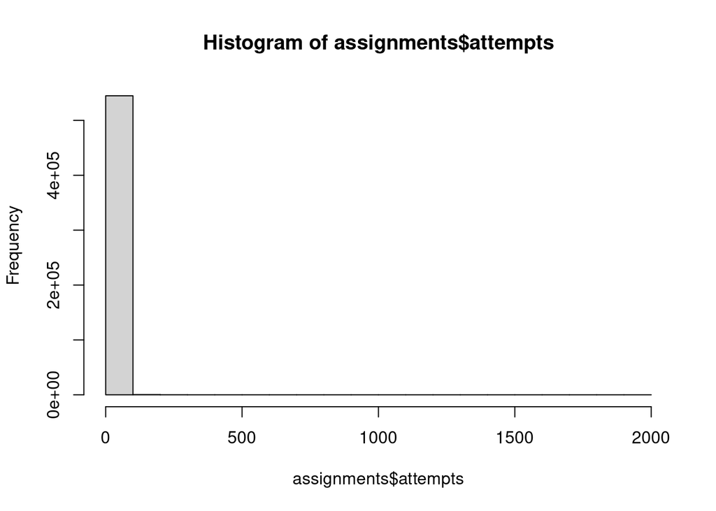

```r
hist(assignments$attempts)
```

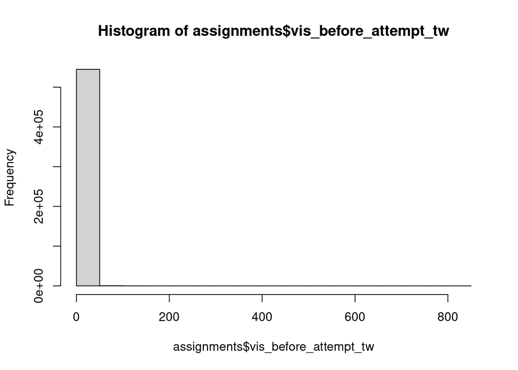

```r
hist(assignments$vis_before_attempt_tw)
```

## 2. Вероятность выполнить задание с первой попытки

#### Дисперсия вероятности выполнить задание с первой попытки по студентам и заданиям

```r
mr0 <- glmer(data = assignments, factor(first_attempt) ~ 1 + (1|hse_user_id) + (1|course_item_name), family = "binomial")
summary(mr0)
```

```
## Generalized linear mixed model fit by maximum likelihood (Laplace
##   Approximation) [glmerMod]
##  Family: binomial  ( logit )
## Formula: factor(first_attempt) ~ 1 + (1 | hse_user_id) + (1 | course_item_name)
##    Data: assignments
##
##       AIC       BIC    logLik  deviance  df.resid
##  496689.2  496722.8 -248341.6  496683.2    545411
##
## Scaled residuals:
##      Min       1Q   Median       3Q      Max
## -21.7196   0.0187   0.3334   0.5273   5.3180
##
## Random effects:
##  Groups           Name        Variance Std.Dev.
##  hse_user_id      (Intercept) 0.7561   0.8695
##  course_item_name (Intercept) 3.7349   1.9326
## Number of obs: 545414, groups:  hse_user_id, 34735; course_item_name, 454
##
## Fixed effects:
##             Estimate Std. Error z value Pr(>|z|)
## (Intercept)  1.80544    0.08359    21.6   <2e-16 ***
## ---
## Signif. codes:  0 '***' 0.001 '**' 0.01 '*' 0.05 '.' 0.1 ' ' 1
```

#### Влияние предварительного посещения форума на вероятность решить задание с первой попытки

```r
mr1 <- glmer(data = assignments, factor(first_attempt) ~ 1 + vis_before_attempt_tw  + (1|hse_user_id) + (1|course_item_name), family = "binomial")
summary(mr1)
```

```
## Generalized linear mixed model fit by maximum likelihood (Laplace
##   Approximation) [glmerMod]
##  Family: binomial  ( logit )
## Formula:
## factor(first_attempt) ~ 1 + vis_before_attempt_tw + (1 | hse_user_id) +
##     (1 | course_item_name)
##    Data: assignments
##
##       AIC       BIC    logLik  deviance  df.resid
##  496524.9  496569.7 -248258.4  496516.9    545410
##
## Scaled residuals:
##    Min     1Q Median     3Q    Max
## -82171      0      0      1      5
##
## Random effects:
##  Groups           Name        Variance Std.Dev.
##  hse_user_id      (Intercept) 0.7571   0.8701
##  course_item_name (Intercept) 3.6219   1.9031
## Number of obs: 545414, groups:  hse_user_id, 34735; course_item_name, 454
##
## Fixed effects:
##                       Estimate Std. Error z value Pr(>|z|)
## (Intercept)            1.79293    0.05570  32.191   <2e-16 ***
## vis_before_attempt_tw  0.11365    0.01372   8.283   <2e-16 ***
## ---
## Signif. codes:  0 '***' 0.001 '**' 0.01 '*' 0.05 '.' 0.1 ' ' 1
##
## Correlation of Fixed Effects:
##             (Intr)
## vs_bfr_ttm_ 0.028
```

```r
mrr1 <- summary(mr1)
```

```r
tab_model(mr1)
```

|  | factor(first attempt) |  |  |
| --- | --- | --- | --- |
| Predictors | Odds Ratios | CI | p |
| (Intercept) | 6.01 | 5.39 – 6.70 | **<0.001** |
| vis_before_attempt_tw | 1.12 | 1.09 – 1.15 | **<0.001** |
| Random Effects |  |  |  |
| σ<sup>2</sup> | 3.29 |  |  |
| τ<sub>00</sub> <sub>hse_user_id</sub> | 0.76 |  |  |
| τ<sub>00</sub> <sub>course_item_name</sub> | 3.62 |  |  |
| ICC | 0.57 |  |  |
| N <sub>hse_user_id</sub> | 34735 |  |  |
| N <sub>course_item_name</sub> | 454 |  |  |
| Observations | 545414 |  |  |
| Marginal R<sup>2</sup> / Conditional R<sup>2</sup> | 0.034 / 0.586 |  |  |

```r
display(mr1)
```

```
## glmer(formula = factor(first_attempt) ~ 1 + vis_before_attempt_tw +
##     (1 | hse_user_id) + (1 | course_item_name), data = assignments,
##     family = "binomial")
##                       coef.est coef.se
## (Intercept)           1.79     0.06
## vis_before_attempt_tw 0.11     0.01
##
## Error terms:
##  Groups           Name        Std.Dev.
##  hse_user_id      (Intercept) 0.87
##  course_item_name (Intercept) 1.90
##  Residual                     1.00
## ---
## number of obs: 545414, groups: hse_user_id, 34735; course_item_name, 454
## AIC = 496525, DIC = 395863.2
## deviance = 446190.0
```

```
## Вероятность, что студент выполнит задание с первой попытки, если до первой попытки он не посещал форум, равна 0.86.
```

[output not shown]

```
## Например, если студент посетил форум 1 раз до совершения попытки,
## то вероятность, что студент выполнит задание будет равна 0.87
```

```
## А если студент посетил форум 25 раз,
## то вероятность, что студент выполнит задание будет равна 0.99
```

#### Визуализация

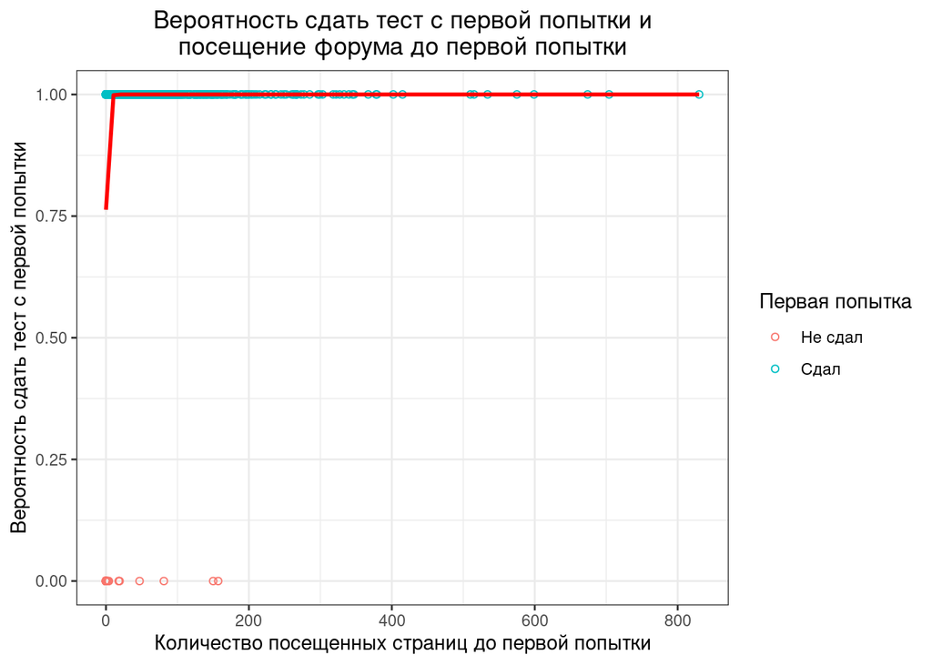

```r
assignments  %>%   ggplot(aes(x = vis_before_attempt_tw, y = first_attempt)) +
  geom_point(aes(color = as.factor(first_attempt)), shape = 1)   +
# построит регрессионную линию, сигмоиду
  geom_smooth(method = "glm", color = "red", method.args=list(family="binomial")) +
# напечатает легенду, название графика и осей
  ggtitle("Вероятность сдать тест с первой попытки и\nпосещение форума до первой попытки") +
  scale_color_discrete(labels=c("Не сдал", "Сдал")) +
  labs(x = "Количество посещенных страниц до первой попытки", y = "Вероятность сдать тест с первой попытки", color = "Первая попытка") +
# задает цветовую тему графика
  theme_bw() +
# выравнивает название по центру
  theme(plot.title = element_text(hjust = 0.5))
```

```r
anova(mr0, mr1)
```

```
## Data: assignments
## Models:
## mr0: factor(first_attempt) ~ 1 + (1 | hse_user_id) + (1 | course_item_name)
## mr1: factor(first_attempt) ~ 1 + vis_before_attempt_tw + (1 | hse_user_id) +
## mr1:     (1 | course_item_name)
##     npar    AIC    BIC  logLik deviance  Chisq Df Pr(>Chisq)
## mr0    3 496689 496723 -248342   496683
## mr1    4 496525 496570 -248258   496517 166.34  1  < 2.2e-16 ***
## ---
## Signif. codes:  0 '***' 0.001 '**' 0.01 '*' 0.05 '.' 0.1 ' ' 1
```

#### Есть ли эффект научения?

Вероятность решить задание с первой попытки может повышаться из-за эффекта научения. Студент может с каждой новой неделей лучше решать задачи. Поэтому возьмем один курс и посмотрим по каждой неделе: есть ли разница между вероятностью решить задание с первой попытки если заходил на форум или не заходил на форум (переменная **vis_before_attempt_tw_b**).

```r
course_branch_items <- fread("../data/vvedenie-mashinnoe-obuchenie/course_branch_items.csv") %>% dplyr::select(course_lesson_id, course_item_id, course_branch_item_name, is_graded)
course_branch_modules <- fread("../data/vvedenie-mashinnoe-obuchenie/course_branch_modules.csv") %>% dplyr::select(course_module_id, course_branch_module_order, course_branch_module_name)
course_branch_lessons <- fread("../data/vvedenie-mashinnoe-obuchenie/course_branch_lessons.csv") %>% dplyr::select(-course_branch_id)

vmo <- left_join(course_branch_lessons, course_branch_items) %>% left_join(., course_branch_modules)

total <- assignments %>%  filter(course_name == "vvedenie-mashinnoe-obuchenie") %>% dplyr::select(course_item_id,  course_item_name, hse_user_id, vis_before_attempt_tw_b, first_attempt) %>%  left_join(., vmo, by="course_item_id") %>% mutate(first_attempt = recode(first_attempt, `1` = "pass", `0` = "fail"), vis_before_attempt_tw_b = recode(vis_before_attempt_tw_b, `1` = "visites", `0` = "not_visited"))
```

Я выбрал курс "Введение в машинное обучение и сравнил вероятность решить задание первой попытки у тех, кто предварительно заходил на форум или не заходил, *отдельно для пяти недель*.

```r
i = 1
while (i < 6) {
  a <- total %>% filter(course_branch_module_order == i)
  tab <- table(a$first_attempt, a$vis_before_attempt_tw_b)
  chisq <- chisq.test(tab)
  cat(sprintf("\nweek %d", i))
  print(tab)
  print(chisq)
  i = i + 1
}
```

```
##
## week 1
##        not_visited visites
##   fail        1986       0
##   pass        4522     147
##
##  Pearson's Chi-squared test with Yates' continuity correction
##
## data:  tab
## X-squared = 62.491, df = 1, p-value = 2.677e-15
##
##
## week 2
##        not_visited visites
##   fail        1840       0
##   pass        6439     280
##
##  Pearson's Chi-squared test with Yates' continuity correction
##
## data:  tab
## X-squared = 77.96, df = 1, p-value < 2.2e-16
##
##
## week 3
##        not_visited visites
##   fail        1765       0
##   pass        4615     406
##
##  Pearson's Chi-squared test with Yates' continuity correction
##
## data:  tab
## X-squared = 150.37, df = 1, p-value < 2.2e-16
##
##
## week 4
##        not_visited visites
##   fail        4077       0
##   pass       13004     952
##
##  Pearson's Chi-squared test with Yates' continuity correction
##
## data:  tab
## X-squared = 292.25, df = 1, p-value < 2.2e-16
##
##
## week 5
##        not_visited visites
##   fail        1493       0
##   pass        5059     236
##
##  Pearson's Chi-squared test with Yates' continuity correction
##
## data:  tab
## X-squared = 67.619, df = 1, p-value < 2.2e-16
```

Видно, что студенты, которые посещали форум почти всегда сдавали задание с первой попытки. Существует значимое различие между студентами, которые посещали форум до первой попытки, и теми, кто не посещал форум до первой попытки.

## 3. Число попыток и посещение форума

Считаем только по выполненным заданиям.

```r
visits_attempts <- assignments %>% filter(assessment_status == 1)
```

```r
mr3 <- glmer(data = visits_attempts, attempts ~ 1 + vis_tw + (1|hse_user_id) + (1|course_item_name), family = "poisson")
summary(mr3)
```

```
## Generalized linear mixed model fit by maximum likelihood (Laplace
##   Approximation) [glmerMod]
##  Family: poisson  ( log )
## Formula: attempts ~ 1 + vis_tw + (1 | hse_user_id) + (1 | course_item_name)
##    Data: visits_attempts
##
##      AIC      BIC   logLik deviance df.resid
##  2236873  2236918 -1118433  2236865   544643
##
## Scaled residuals:
##     Min      1Q  Median      3Q     Max
## -22.409  -0.816  -0.341   0.299 146.211
##
## Random effects:
##  Groups           Name        Variance Std.Dev.
##  hse_user_id      (Intercept) 1.139    1.067
##  course_item_name (Intercept) 6.660    2.581
## Number of obs: 544647, groups:  hse_user_id, 34735; course_item_name, 454
##
## Fixed effects:
##               Estimate Std. Error z value Pr(>|z|)
## (Intercept) -4.232e-01  8.893e-02  -4.759 1.95e-06 ***
## vis_tw       6.503e-03  3.888e-05 167.254  < 2e-16 ***
## ---
## Signif. codes:  0 '***' 0.001 '**' 0.01 '*' 0.05 '.' 0.1 ' ' 1
##
## Correlation of Fixed Effects:
##        (Intr)
## vis_tw -0.001
## convergence code: 0
## Model failed to converge with max|grad| = 0.00335742 (tol = 0.002, component 1)
## Model is nearly unidentifiable: very large eigenvalue
##  - Rescale variables?
## Model is nearly unidentifiable: large eigenvalue ratio
##  - Rescale variables?
```

```r
mrr3 <- summary(mr3)
```

```
## Ожидаемое число попыток, чтобы выполнить задание, без посещения форума равно 0.65.
```

```
## С увеличением числа посещенных страниц на 1 пункт ожидаемое число попыток увеличиться в 1.01 раз, т.е. на 0 %.
```

```
## Например, если студент посетил форум 25 раз, то ожидаемое число попыток, которое он сделает равно 0.77058.
```